# Code in class

## Boxplots

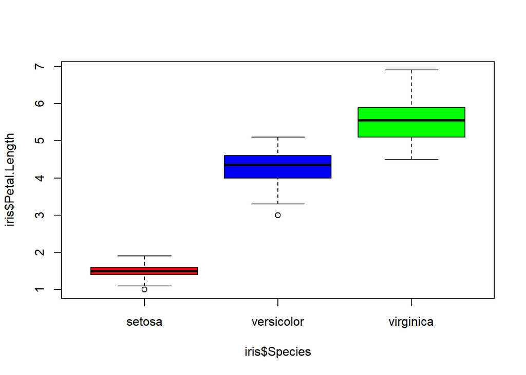

```r
boxplot(iris$Petal.Length ~ iris$Species,
        col=c("red", "blue", "green"))
```

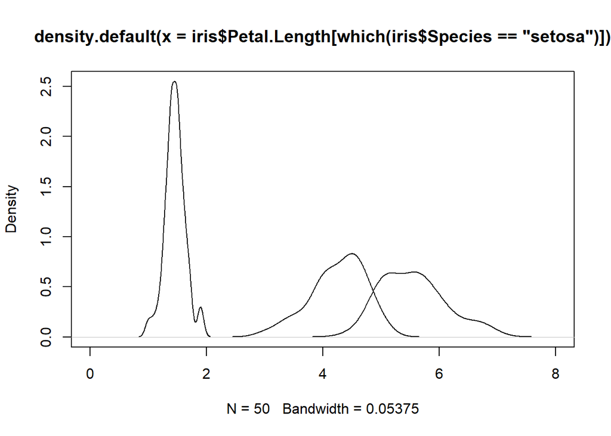

```r
## Density plots
## Hint: which function to select species
## lines()
plot(density(iris$Petal.Length[which(iris$Species ==
                                       "setosa")]),
     xlim=c(0,8))
lines(density(iris$Petal.Length[which(iris$Species ==
                                       "virginica")]))
lines(density(iris$Petal.Length[which(iris$Species ==
                                       "versicolor")]))
```

# Help

```r
#R is case sensitive.
#R index starts from 1

####Help
#Help Home Page, Special Character Help, Search Help, Search Function (with partial name)
#
# help.start()
#
# help('$')
#
# ?"$"

# apropos('med')

example(median)
```

```
##
## median> median(1:4)                # = 2.5 [even number]
## [1] 2.5
##
## median> median(c(1:3, 100, 1000))  # = 3 [odd, robust]
## [1] 3
```

```r
# help(package = "dplyr")

#Get help on a function of a package
# help("tally", package = "dplyr")
```

# R basics

```r
####Basics

# The arrow operator (<-) sets the left-hand side equal to the right-hand side.
# It computes a1 and assigns it to the variable a2
#a2<- a1

a1 <- 6 + 7
a2 <- a1
# View(a2)

rm(a2)

#Comments starts with #


####R Built-in Data Sets
# data()

# Loading datasets
data(mtcars)

# Print the first 6 rows of a dataset
head(mtcars, 6)
```

|  | mpg | cyl | disp | hp | drat | wt | qsec | vs | am | gear | carb |
| --- | --- | --- | --- | --- | --- | --- | --- | --- | --- | --- | --- |
| Mazda RX4 | 21.0 | 6 | 160 | 110 | 3.90 | 2.620 | 16.46 | 0 | 1 | 4 | 4 |
| Mazda RX4 Wag | 21.0 | 6 | 160 | 110 | 3.90 | 2.875 | 17.02 | 0 | 1 | 4 | 4 |
| Datsun 710 | 22.8 | 4 | 108 | 93 | 3.85 | 2.320 | 18.61 | 1 | 1 | 4 | 1 |
| Hornet 4 Drive | 21.4 | 6 | 258 | 110 | 3.08 | 3.215 | 19.44 | 1 | 0 | 3 | 1 |
| Hornet Sportabout | 18.7 | 8 | 360 | 175 | 3.15 | 3.440 | 17.02 | 0 | 0 | 3 | 2 |
| Valiant | 18.1 | 6 | 225 | 105 | 2.76 | 3.460 | 20.22 | 1 | 0 | 3 | 1 |

```r
# ?mtcars

# Number of rows (observations)
nrow(mtcars)
```

```
## [1] 32
```

```r
# Number of columns (variables)
ncol(mtcars)
```

```
## [1] 11
```

```r
data(iris)


# You could find a large number of datasets at https://archive.ics.uci.edu/ml/datasets.php
```

# Using Packages

You could find a large number of datasets at https://archive.ics.uci.edu/ml/datasets.php

## Using Packages

R packages: collections of functions and data sets developed by the community. Examples: “dplyr” or “data.table”

A number of packages are automatically loaded when you start R (e.g., “base”, “utils”, “graphics”, and “stats”)

First you install packages and then you should load them using command “library()”

## install & load library()

install packages() install.packages(“tidyr”)

library(tidyr) browseVignettes()

browseVignettes(package=“packagename”)

vignette(package = “ggplot2”)

## Unload packages

detach(packageName)

## require(ggplot2)

# Working Directory

current working directory where inputs are found, and outputs are sent.

getwd()

## Change the current working directory.

setwd(C://file/path)

## What working directory are we in?

Set working directory to a new place !!! You need to change this! setwd(‘/Users/kravvaz/Desktop/PH718_spring20/Lecture2’)

```r
### Try the following commands
getwd() ## Get working directory
```

```
## [1] "C:/Users/anemati/OneDrive - mcw.edu/UWM/Spring/PH 718 R/R code In class"
```

```r
dir()   ## What else is in that directory?
```

```
##  [1] "code-in-class.html"       "code-in-class.pdf"
##  [3] "code-in-class.Rmd"        "code-in-class_files"
##  [5] "code in class.Rmd"        "comment"
##  [7] "cowplot.R"                "first package"
##  [9] "first_rmarkdown.docx"     "first_rmarkdown.pdf"
## [11] "first_rmarkdown.Rmd"      "ggplot.pdf"
## [13] "ggplot.Rmd"               "Lecture1_Rcode1.R"
## [15] "Lecture1_Rcode1.R.ipynb"  "Lecture1_Rcode2.R"
## [17] "Lecture2_Rcode.R"         "Lecture3_Rcode.R"
## [19] "Lecture4_Rcode.R"         "mypackage"
## [21] "R class 02-03-2021.r"     "R code for bio.Rproj"
## [23] "test-figure"              "Untitled.ipynb"
## [25] "W2_1_Lecture2_Rcode.R"    "W2_2_errorExamples.R"
## [27] "W2_3_first_rmarkdown.Rmd" "weel1.R"
```

```r
objects()
```

```
##  [1] "a1"               "col_vector"       "gen_exp"          "high_index"
##  [5] "iris"             "mtcars"           "my_df"            "my_huge_matrix"
##  [9] "my_matrix"        "my_matrix_2"      "my_name_vector"   "my_normal_vector"
## [13] "my_vector"        "setosa_index"     "shape_vector"     "versicolor_index"
## [17] "virginica_index"
```

```r
ls()
```

```
##  [1] "a1"               "col_vector"       "gen_exp"          "high_index"
##  [5] "iris"             "mtcars"           "my_df"            "my_huge_matrix"
##  [9] "my_matrix"        "my_matrix_2"      "my_name_vector"   "my_normal_vector"
## [13] "my_vector"        "setosa_index"     "shape_vector"     "versicolor_index"
## [17] "virginica_index"
```

```r
rm(list=c("x", "y"))
ls()
```

```
##  [1] "a1"               "col_vector"       "gen_exp"          "high_index"
##  [5] "iris"             "mtcars"           "my_df"            "my_huge_matrix"
##  [9] "my_matrix"        "my_matrix_2"      "my_name_vector"   "my_normal_vector"
## [13] "my_vector"        "setosa_index"     "shape_vector"     "versicolor_index"
## [17] "virginica_index"
```

# Data Types

- Numeric (float/double, integer, etc.)
- Character(string)
- Date (common packages: lubridate, chron)
- Logical (TRUE = 1, FALSE = 0, ==, !=)
- Factor (Character strings with preset levels.)

## Example of data type

```r
a1 <- 6 + 7
a2 <- a1

is.numeric(a2)
```

```
## [1] TRUE
```

```r
nchar(mtcars$hp)
```

```
##  [1] 3 3 2 3 3 3 3 2 2 3 3 3 3 3 3 3 3 2 2 2 2 3 3 3 3 2 2 3 3 3 3 3
```

```r
#Stores just as a date.
date1 <- as.Date('2020-01-23')

#Internally, Date objects are stored as the number of days since January 1, 1970
#To convert a Date object to its internal form, number of days since 1/1/1970.
as.numeric(date1)
```

```
## [1] 18284
```

```r
#Stores a date and time.
date2 <- as.POSIXct("2020-01-23 17:30")
#In numeric form, number of seconds since 1/1/1970.
as.numeric(date2)
```

```
## [1] 1579822200
```

```r
as.numeric(TRUE)
```

```
## [1] 1
```

```r
class(iris$Species)
```

```
## [1] "factor"
```

```r
levels(iris$Species)
```

```
## [1] "setosa"     "versicolor" "virginica"
```

```r
str(iris$Species)
```

```
##  Factor w/ 3 levels "setosa","versicolor",..: 1 1 1 1 1 1 1 1 1 1 ...
```

# Data Structures

- Vector (Groups of elements of the SAME type)
- Factor (A vector of categorical variables, encoded using integers)
- List (Store any number of items of ANY type)
- Data Frame (DATA.FRAME)(Each column is a variable, each row is an observation)
- Data Table (DATA.TABLE) (Extends and enhances the functionality of data.frames, index like a database, data.table does not turn character data into factors but data.frame does.)
- Matrix (Similar to data.frame except every element must be the SAME type)
- Array (Multidimensional vector of the SAME type)

```r
v1 <- c(1, 2, 3, 4, 5, 6, 7, 8)
length(v1)
```

```
## [1] 8
```

```r
unique(v1)
```

```
## [1] 1 2 3 4 5 6 7 8
```

```r
rev(v1)
```

```
## [1] 8 7 6 5 4 3 2 1
```

```r
v1[order(v1)]
```

```
## [1] 1 2 3 4 5 6 7 8
```

```r
v1[v1 > 3]
```

```
## [1] 4 5 6 7 8
```

```r
v1[1:3]
```

```
## [1] 1 2 3
```

```r
v1[c(1,6)]
```

```
## [1] 1 6
```

```r
v1[-(2:4)]
```

```
## [1] 1 5 6 7 8
```

```r
v1[v1 == 5]
```

```
## [1] 5
```

```r
v1[v1 %in% c(1, 2, 5)]
```

```
## [1] 1 2 5
```

```r
v1 <- c(1, 2, 3, 4, 5, 6, 7, 8)
v1 <- 1:8
v1 <- seq(from=1, to=8, by=1)

#row.names(data.frame)
#nrow()
#length()
#subset(data.frame, [condition])
#rbind()
```

## Vector

```r
# with numerics from 1 up to 10
my_vector <- 1:10
my_vector
```

```
##  [1]  1  2  3  4  5  6  7  8  9 10
```

## Matrix

```r
# with numerics from 1 up to 9
my_matrix <- matrix(1:9, ncol = 3)
my_matrix
```

```
##      [,1] [,2] [,3]
## [1,]    1    4    7
## [2,]    2    5    8
## [3,]    3    6    9
```

## data frame

```r
#First 10 elements of the built-in data frame mtcars
my_df <- mtcars[1:10,]
my_df
```

|  | mpg | cyl | disp | hp | drat | wt | qsec | vs | am | gear | carb |
| --- | --- | --- | --- | --- | --- | --- | --- | --- | --- | --- | --- |
| Mazda RX4 | 21.0 | 6 | 160.0 | 110 | 3.90 | 2.620 | 16.46 | 0 | 1 | 4 | 4 |
| Mazda RX4 Wag | 21.0 | 6 | 160.0 | 110 | 3.90 | 2.875 | 17.02 | 0 | 1 | 4 | 4 |
| Datsun 710 | 22.8 | 4 | 108.0 | 93 | 3.85 | 2.320 | 18.61 | 1 | 1 | 4 | 1 |
| Hornet 4 Drive | 21.4 | 6 | 258.0 | 110 | 3.08 | 3.215 | 19.44 | 1 | 0 | 3 | 1 |
| Hornet Sportabout | 18.7 | 8 | 360.0 | 175 | 3.15 | 3.440 | 17.02 | 0 | 0 | 3 | 2 |
| Valiant | 18.1 | 6 | 225.0 | 105 | 2.76 | 3.460 | 20.22 | 1 | 0 | 3 | 1 |
| Duster 360 | 14.3 | 8 | 360.0 | 245 | 3.21 | 3.570 | 15.84 | 0 | 0 | 3 | 4 |
| Merc 240D | 24.4 | 4 | 146.7 | 62 | 3.69 | 3.190 | 20.00 | 1 | 0 | 4 | 2 |
| Merc 230 | 22.8 | 4 | 140.8 | 95 | 3.92 | 3.150 | 22.90 | 1 | 0 | 4 | 2 |
| Merc 280 | 19.2 | 6 | 167.6 | 123 | 3.92 | 3.440 | 18.30 | 1 | 0 | 4 | 4 |

## list

```r
#Construct list with these different elements:
my_list <- list(my_vector, my_matrix, my_df)
my_list
```

```
## [[1]]
##  [1]  1  2  3  4  5  6  7  8  9 10
##
## [[2]]
##      [,1] [,2] [,3]
## [1,]    1    4    7
## [2,]    2    5    8
## [3,]    3    6    9
##
## [[3]]
##                    mpg cyl  disp  hp drat    wt  qsec vs am gear carb
## Mazda RX4         21.0   6 160.0 110 3.90 2.620 16.46  0  1    4    4
## Mazda RX4 Wag     21.0   6 160.0 110 3.90 2.875 17.02  0  1    4    4
## Datsun 710        22.8   4 108.0  93 3.85 2.320 18.61  1  1    4    1
## Hornet 4 Drive    21.4   6 258.0 110 3.08 3.215 19.44  1  0    3    1
## Hornet Sportabout 18.7   8 360.0 175 3.15 3.440 17.02  0  0    3    2
## Valiant           18.1   6 225.0 105 2.76 3.460 20.22  1  0    3    1
## Duster 360        14.3   8 360.0 245 3.21 3.570 15.84  0  0    3    4
## Merc 240D         24.4   4 146.7  62 3.69 3.190 20.00  1  0    4    2
## Merc 230          22.8   4 140.8  95 3.92 3.150 22.90  1  0    4    2
## Merc 280          19.2   6 167.6 123 3.92 3.440 18.30  1  0    4    4
```

## Factor

```r
#How to create a factor?
factor1 <- factor(c("single", "married", "married", "single"))
factor1
```

```
## [1] single  married married single
## Levels: married single
```

```r
factor2 <- factor(c("single", "married", "married", "single"),
                levels = c("single", "married", "divorced"));
factor2
```

```
## [1] single  married married single
## Levels: single married divorced
```

```r
class(factor2)
```

```
## [1] "factor"
```

```r
levels(factor2)
```

```
## [1] "single"   "married"  "divorced"
```

```r
factor3 <- factor(c("single","married","married","single"))
str(factor3)
```

```
##  Factor w/ 2 levels "married","single": 2 1 1 2
```

```r
#How to access components of a factor?
factor3
```

```
## [1] single  married married single
## Levels: married single
```

```r
factor3[3]           # access 3rd element
```

```
## [1] married
## Levels: married single
```

```r
factor3[c(2, 4)]     # access 2nd and 4th element
```

```
## [1] married single
## Levels: married single
```

```r
factor3[-1]          # access all but 1st element
```

```
## [1] married married single
## Levels: married single
```

```r
factor3[c(TRUE, FALSE, FALSE, TRUE)]  # using logical vector
```

```
## [1] single single
## Levels: married single
```

```r
#How to modify a factor?
factor3
```

```
## [1] single  married married single
## Levels: married single
```

```r
factor3[2] <- "divorced"    # modify second element;
factor3[3] <- "widowed"    # cannot assign values outside levels
factor3
```

```
## [1] single <NA>   <NA>   single
## Levels: married single
```

```r
#Add a value to the level first.
levels(factor3) <- c(levels(factor3), "widowed")    # add new level
factor3[3] <- "widowed"
factor3
```

```
## [1] single  <NA>    widowed single
## Levels: married single widowed
```

```r
#NA
#Missing data is encoded using value NA.
is.na(factor3) #tests whether factor3 is an NA
```

```
## [1] FALSE  TRUE FALSE FALSE
```

# Plot

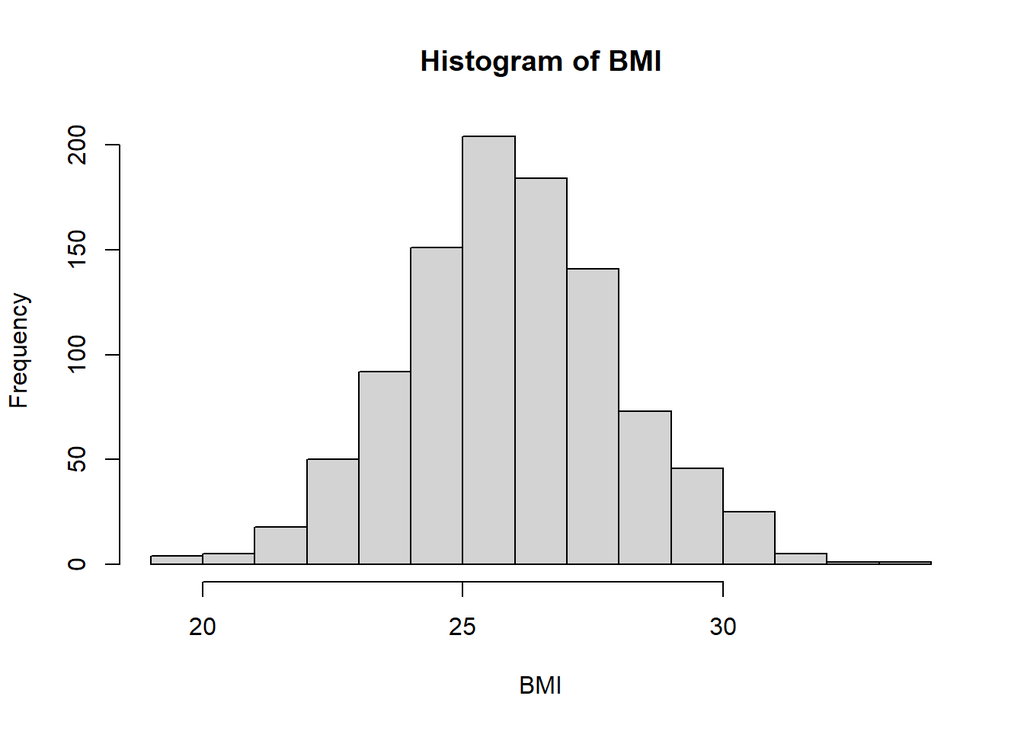

```r
###
set.seed(2020)
BMI<-rnorm(n=1000, m=26, sd=2)
hist(BMI)
```

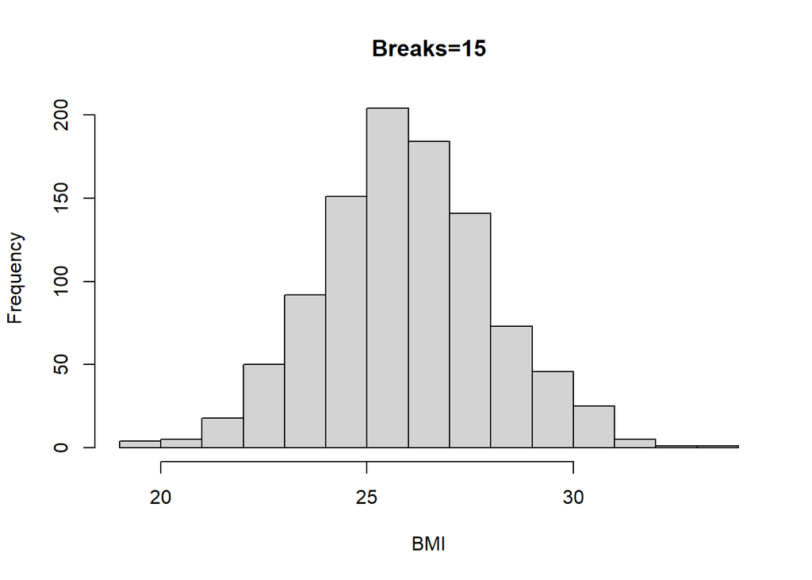

```r
hist(BMI, breaks=15, main="Breaks=15")
```

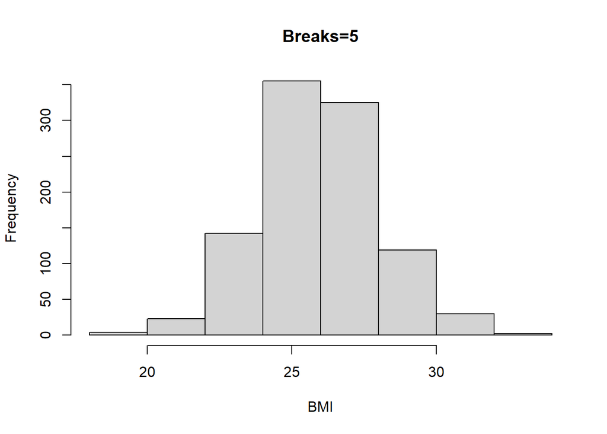

```r
hist(BMI, breaks=5, main="Breaks=5")
```

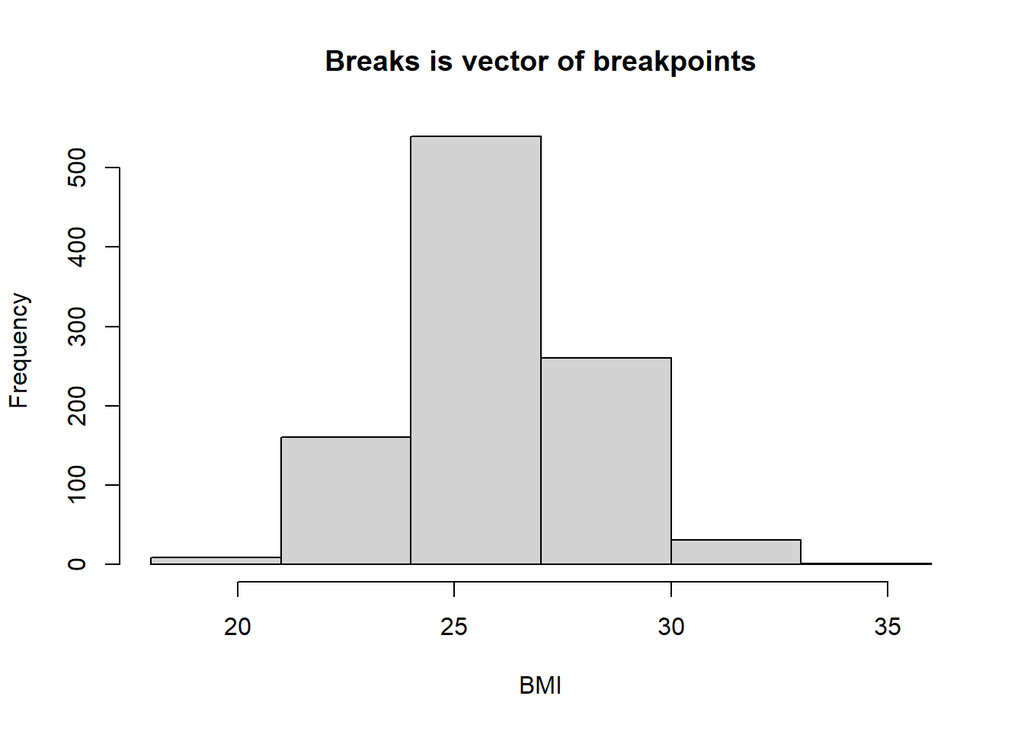

```r
#breaks() option with a vector gives you more control over exactly the breakpoints between bins by dictating the start and end point of each bin.
hist(BMI, breaks=c(18, 21, 24, 27, 30, 33, 36), main="Breaks is vector of breakpoints")

hist(BMI, breaks=seq(18,36,by=3), main="Breaks is vector of breakpoints")
```

[output not shown]

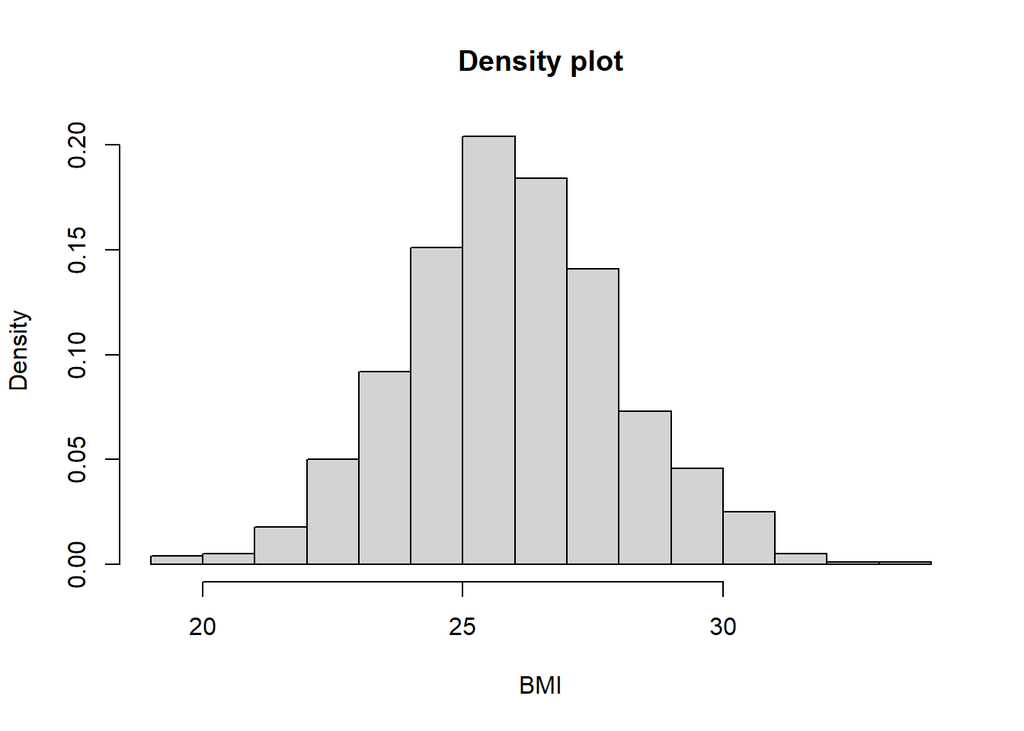

```r
#Density plot: freq=FALSE option
hist(BMI, freq=FALSE, main="Density plot")
```

# Functions in R

## Here is a simple example

```r
#
example.sum <- function(a, b) {
  return(a + b)
}

x <- 1:10
y <- 11:20
example.sum(x, y)
```

```
##  [1] 12 14 16 18 20 22 24 26 28 30
```

```r
### Naming conventions. Why not write example.sum() as:
example.sum.1 <- function(x, y, z) {
  tmp <- x + y
  tmp2 <- tmp + z
  return(tmp2)
}
x <- 1:10
y <- 11:20
z <- 100
example.sum.1(x, y, z)
```

```
##  [1] 112 114 116 118 120 122 124 126 128 130
```

```r
### Try this

example.diff.sum <- function(x, y) {
  newy = example.sum(x, y) - 10
  return(newy)
}
# example.diff.sum(x, y)
example.diff.sum(10, 5)
```

```
## [1] 5
```

```r
example.sum = function(a, b) {
  return(a + b)
}

example.diff.sum = function(c, d) {
  e = example.sum(c, d) - 10
  return(e)
}

x <- 1:10
y <- 11:20
# example.diff.sum(x, y)
example.diff.sum(10, 5)
```

```
## [1] 5
```

## Example together: Hardy-Weinberg problem #3.6 from book

```r
HWE <- function(p) {
  stopifnot(is.numeric(p))
  stopifnot(p >= 0)
  stopifnot(p <= 1)
  prob_AA <- p ^ 2
  prob_AB <- 2 * p * (1 - p)
  prob_BB <- (1 - p) ^ 2
  return(c(prob_AA, prob_AB, prob_BB))
}
HWE(0)
```

```
## [1] 0 0 1
```

```r
HWE(0.5)
```

```
## [1] 0.25 0.50 0.25
```

```r
# HWE(-5) # Error
# HWE("kourosh") # Error
```

## Write a function to convert Celsuis to Fahrenheit and vice versa

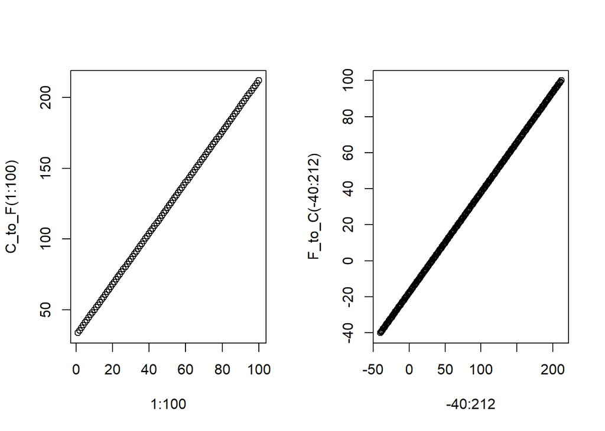

```r
C_to_F <- function(temp) {
  return((temp * 1.8) + 32)
}

F_to_C <- function(temp) {
  return((temp - 32) / 1.8)
}

par(mfrow = c(1, 2))
plot(1:100, C_to_F(1:100))
plot(-40:212, F_to_C(-40:212))
```

## type_of_conversion can be “F_to_C” or “C_to_F”

```r
temp_conversion <- function(temp, type_of_conversion = "F_to_C") {
  if (!type_of_conversion %in% c("F_to_C", "C_to_F")) {
    stop("STOP!!! I can only convert C to F or F to C.")
  }
  if (type_of_conversion == "F_to_C") {
    new_temp <- F_to_C(temp)
  }
  if (type_of_conversion == "C_to_F") {
    new_temp <- C_to_F(temp)
  }
  return(list(temp = new_temp, conversion = type_of_conversion))
}

temp_conversion(100, type = "C_to_F")
```

```
## $temp
## [1] 212
##
## $conversion
## [1] "C_to_F"
```

```r
temp_conversion(0, type = "F_to_C")
```

```
## $temp
## [1] -17.77778
##
## $conversion
## [1] "F_to_C"
```

# Loops in R

An introductory example

This “initializes” the object “w” so that R knows what w “stands for.”

w <- NULL

## for loop

```r
w <- NULL
for (i in 1:10) {
  w[i] <- i + 10
}
w
```

```
##  [1] 11 12 13 14 15 16 17 18 19 20
```

## What do you think w looks like?

```r
#w <- NULL
for (hello in 1:10) {
  w[hello] <- hello
}
w
```

```
##  [1]  1  2  3  4  5  6  7  8  9 10
```

Now what does w look like?

## embed loops

```r
w <- NULL
counter <- 1
for (j in 11:20) {
  for (i in 1:10) {
    w[counter] <- i + j
    counter <- counter + 1
  }
}
w
```

```
##   [1] 12 13 14 15 16 17 18 19 20 21 13 14 15 16 17 18 19 20 21 22 14 15 16 17 18
##  [26] 19 20 21 22 23 15 16 17 18 19 20 21 22 23 24 16 17 18 19 20 21 22 23 24 25
##  [51] 17 18 19 20 21 22 23 24 25 26 18 19 20 21 22 23 24 25 26 27 19 20 21 22 23
##  [76] 24 25 26 27 28 20 21 22 23 24 25 26 27 28 29 21 22 23 24 25 26 27 28 29 30
```

Think through these two loops carefully.

## What is the difference between this loop and the last loop?

```r
w <- NULL
w
```

[output not shown]

```r
counter <- 1
for (j in 11:20) {
  for (i in 1:10) {
    w[counter] <- i + j
  }
  counter <- counter + 1
}
w
```

```
##  [1] 21 22 23 24 25 26 27 28 29 30
```

## An example of a “while” loop

```r
w <- 100
z <- 5

while (w > 20) {
  w.plus.z <- w + z
  w <- w - 1
}
w
```

```
## [1] 20
```

```r
w <- 100
z <- 5
while (w < 20) {
  # if w > 20 => inf loop
  w.plus.z <- w + z
  w <- w + 1
}
w
```

```
## [1] 100
```

## Indices and the which() function

```r
x <- rnorm(100)
x[1:10]
```

```
##  [1]  0.00465041 -1.22874970 -0.14059798 -0.20732697 -0.92153058  0.36047424
##  [7]  1.66660243  1.44804634 -0.03285159 -1.62843554
```

```r
x[20:30]
```

```
##  [1]  0.18713551 -0.57543743 -0.08766336  0.31167076  0.24438772 -0.45803324
##  [7]  1.32593062 -0.57952274 -0.82407695  1.08562056  1.41590793
```

```r
index <- which(x < 0)

index
```

```
##  [1]   2   3   4   5   9  10  11  13  14  15  17  18  19  21  22  25  27  28  33
## [20]  35  38  41  44  45  46  49  52  57  58  60  63  64  65  66  68  72  73  74
## [39]  75  78  80  81  83  84  85  89  90  93  94  96  97 100
```

```r
x[index]
```

```
##  [1] -1.22874970 -0.14059798 -0.20732697 -0.92153058 -0.03285159 -1.62843554
##  [7] -0.56266928 -0.85173525 -0.91512892 -0.44484557 -1.44896422 -0.59389701
## [13] -0.75144575 -0.57543743 -0.08766336 -0.45803324 -0.57952274 -0.82407695
## [19] -2.07172304 -0.49889987 -1.51680685 -0.62976566 -0.36027572 -0.39350268
## [25] -1.04180068 -0.63945719 -0.85649561 -0.38280458 -1.89724701 -0.69186589
## [31] -0.43251556 -0.95196059 -0.21625030 -1.04279172 -0.10986728 -1.84878973
## [37] -0.98415680 -0.21854832 -0.80092215 -0.50991847 -0.09837813 -0.83113845
## [43] -0.19782135 -0.54494659 -0.32692897 -0.25978735 -0.11579965 -0.93762421
## [49] -0.27231887 -0.47014392 -0.06493665 -0.96108831
```